# Null Threshold Search for Binary Outcomes

- Show All Code
- Hide All Code
- View Source

Approximation-Driven Selection with Simulation Validation

Author

Larry F. Leon

Published

April 16, 2026

# 1 Setup

```r
library(forestsearch)
library(data.table)
library(ggplot2)
library(patchwork)
library(gt)
library(foreach)
library(doFuture)
library(future)

# -- Safe foreach result collection -------------------------------------------
# collect_results() now lives in forestsearch (R/forestsearch_helpers.R).
# Called via ::: since it is an internal (unexported) utility.
```

```r
timings <- list(leff_cal = 0, validation = 0, power = 0)
t_vignette_start <- proc.time()
```

```r
# Diagnostic: confirm working directory and .rds availability
cat(sprintf("Working directory: %s\n", getwd()))
```

```
#> Working directory: /media/larryleon/My Projects/GitHub/forestsearch/quarto/calibration
```

```r
cal_rds <- file.path(output_dir, "calibration_binary_leff.rds")
cat(sprintf("Looking for: %s → %s\n",
            cal_rds, if (file.exists(cal_rds)) "FOUND" else "NOT FOUND"))
```

```
#> Looking for: ../_data/calibration_binary_leff.rds → FOUND
```

```r
# Load L_eff calibration from C1 (calibration_binary_leff.qmd)
cal_binary <- tryCatch(
  load_leff_calibration("binary", output_dir = output_dir),
  error = function(e) {
    message("Calibration .rds not found: ", e$message)
    message("Using fallback values from setup chunk.")
    list(C = C_prior_fallback, alpha = alpha_prior_fallback,
         n_min = 60L, source = "fallback (hardcoded)",
         extra = list())
  }
)
```

```
#> === L_eff Calibration: binary ===
```

```
#>   C = 2.6801, alpha = 0.1313, n_min = 60
```

```
#>   DGM: Binary DGM, 4 confounders (bm1, bm2, age, ecog), p(event)=0.30, 30% harm prevalence
```

```
#>   Sims per N: 2000
```

```
#>   Calibrated: 2026-04-16 03:26
```

```
#>   N values: 300, 500, 700
```

```r
C_prior     <- cal_binary$C
alpha_prior <- cal_binary$alpha

# Inherit shared parameters from C1's config (if available)
cfg <- cal_binary$extra
if (length(cfg) > 0) {
  cat("=== Inheriting config from C1 calibration ===\n")
  if (!is.null(cfg$p_event))          p_event          <- cfg$p_event
  if (!is.null(cfg$p_harm))           p_harm           <- cfg$p_harm
  if (!is.null(cfg$theta_h1))         theta_h1         <- cfg$theta_h1
  if (!is.null(cfg$confounders_name)) confounders_name <- cfg$confounders_name
  if (!is.null(cfg$pcons))            pcons            <- cfg$pcons
  if (!is.null(cfg$fs_splits))        fs_splits        <- cfg$fs_splits
  if (!is.null(cfg$maxk_val))         maxk_val         <- cfg$maxk_val
  if (!is.null(cfg$N_cal_values))     N_cal_values     <- cfg$N_cal_values
  # NOTE: fpr_target is intentionally NOT inherited from C1.
  # It is a policy parameter set in the setup chunk of this document.
  cat(sprintf("  confounders: %s\n", paste(confounders_name, collapse = ", ")))
  cat(sprintf("  p_event=%.2f, pcons=%.2f, fs_splits=%d, maxk=%d\n",
              p_event, pcons, fs_splits, maxk_val))
  cat(sprintf("  N_cal=%s\n", paste(N_cal_values, collapse = ", ")))
  cat(sprintf("  fpr_target=%.2f (from setup chunk, not inherited)\n",
              fpr_target))

  # Grid range: clamp to C1's validated range or warn
  if (!is.null(cfg$c1_range) && !is.null(cfg$c2_range)) {
    if (use_c1_grid) {
      # Default: adopt C1's validated range with S1's step size
      c1_grid <- seq(cfg$c1_range[1], cfg$c1_range[2], by = grid_step)
      c2_grid <- seq(cfg$c2_range[1], cfg$c2_range[2], by = grid_step)
      cat(sprintf("  Grid clamped to C1's validated range:\n"))
      cat(sprintf("    c1_grid = seq(%.2f, %.2f, by = %.2f) [%d values]\n",
                  min(c1_grid), max(c1_grid), grid_step, length(c1_grid)))
      cat(sprintf("    c2_grid = seq(%.2f, %.2f, by = %.2f) [%d values]\n",
                  min(c2_grid), max(c2_grid), grid_step, length(c2_grid)))
    } else {
      # User override: keep setup-chunk grid, warn if out of range
      cat("  Grid: using user-specified values (use_c1_grid = FALSE)\n")
      if (min(c1_grid) < cfg$c1_range[1] ||
          max(c1_grid) > cfg$c1_range[2]) {
        warning(sprintf(paste0(
          "S1 c1_grid [%.2f, %.2f] extends beyond C1's validated ",
          "range [%.2f, %.2f].\n",
          "  L_eff threshold-independence is unverified outside ",
          "this range.\n",
          "  Consider expanding c1_grid in C1 and re-running."),
          min(c1_grid), max(c1_grid),
          cfg$c1_range[1], cfg$c1_range[2]),
          call. = FALSE)
      }
      if (min(c2_grid) < cfg$c2_range[1] ||
          max(c2_grid) > cfg$c2_range[2]) {
        warning(sprintf(paste0(
          "S1 c2_grid [%.2f, %.2f] extends beyond C1's validated ",
          "range [%.2f, %.2f].\n",
          "  Consider expanding c2_grid in C1 and re-running."),
          min(c2_grid), max(c2_grid),
          cfg$c2_range[1], cfg$c2_range[2]),
          call. = FALSE)
      }
    }
  } else {
    cat("  Grid range: no C1 range info; using setup-chunk values.\n")
  }
} else {
  cat("=== Using fallback config from setup chunk ===\n")
  cat("(C1 .rds not found or has no extra config)\n")
}
```

```
#> === Inheriting config from C1 calibration ===
#>   confounders: bm1, bm2, age, ecog
#>   p_event=0.30, pcons=0.90, fs_splits=400, maxk=2
#>   N_cal=300, 500, 700
#>   fpr_target=0.15 (from setup chunk, not inherited)
#>   Grid clamped to C1's validated range:
#>     c1_grid = seq(1.50, 2.50, by = 0.05) [21 values]
#>     c2_grid = seq(1.00, 2.00, by = 0.05) [21 values]
```

```r
cat(sprintf("\nL_eff prior: C = %.4f, alpha = %.4f\n",
            C_prior, alpha_prior))
```

```
#>
#> L_eff prior: C = 2.6801, alpha = 0.1313
```

```r
if (!is.null(cal_binary$dgm_description))
  cat(sprintf("Source: %s\n", cal_binary$dgm_description))
```

```
#> Source: Binary DGM, 4 confounders (bm1, bm2, age, ecog), p(event)=0.30, 30% harm prevalence
```

```r
if (!is.null(cal_binary$timestamp))
  cat(sprintf("Calibrated: %s\n",
              format(cal_binary$timestamp, "%Y-%m-%d %H:%M")))
```

```
#> Calibrated: 2026-04-16 03:26
```

```r
# Saturation floor: warn if the approximation grid dips below the
# threshold range where L_eff was validated in C1.
saturation_floor_c1 <- cfg$saturation_floor_c1
if (!is.null(saturation_floor_c1)) {
  cat(sprintf("\nSaturation floor (from C1): c1 >= %.2f\n",
              saturation_floor_c1))
  if (min(c1_grid) < saturation_floor_c1) {
    warning(sprintf(paste0(
      "S1 c1_grid starts at %.2f, below C1's saturation floor of %.2f.\n",
      "  Corrected FPR values at c1 < %.2f are unreliable (L_eff overestimated).\n",
      "  Raise min(c1_grid) or set use_c1_grid = TRUE to clamp to C1's range."),
      min(c1_grid), saturation_floor_c1, saturation_floor_c1),
      call. = FALSE)
  } else {
    cat("  Grid is above saturation floor: corrected FPR is reliable.\n")
  }
} else {
  cat("\n(No saturation floor in .rds — re-run C1 to record it.)\n")
}
```

```
#>
#> Saturation floor (from C1): c1 >= 1.50
#>   Grid is above saturation floor: corrected FPR is reliable.
```

**NoteCalibration Source and Threshold-Independence Requirement**

The $L_{\text{eff}}$ prior and shared ForestSearch parameters were loaded from `_data/calibration_binary_leff.rds`, produced by `calibration_binary_leff.qmd` (C1).

- **If the `.rds` exists:** inherits `p_event`, `confounders_name`, `pcons`, `fs_splits`, `maxk_val`, and `N_cal_values` from C1’s config. `fpr_target` is **not** inherited — it is a policy parameter set in the setup chunk of this document.
- **Grid range** (`use_c1_grid = TRUE`, default): `c1_grid` and `c2_grid` are set to C1’s *non-saturated* validated range at S1’s `grid_step`. Set `use_c1_grid = FALSE` to use the setup-chunk values instead (a warning is printed if they extend beyond C1’s validated range).
- **If `.rds` not found:** uses the fallback values defined in the setup chunk.
- **To recalibrate from scratch:** set `recalibrate = TRUE`.

**ImportantThe Saturation Floor — Why the Grid Must Stay Within C1’s Range**

The $L_{\text{eff}}$ framework assumes that the corrected FPR formula $1 - (1-P_1)^{L_{\text{eff}}}$ is applied only within the threshold range where $L_{\text{eff}}$ is threshold-independent.

For binary outcomes with small $d_{\text{eff}}$, there is a **saturation floor** below which the simulated FPR is insensitive to $(c_1, c_2)$ because essentially all candidate subgroups exceed the threshold by sampling noise. The implied $L_{\text{eff}}$ is inflated in this regime. If the calibrated $L_{\text{eff}}$ is extrapolated back to these low thresholds it will **overestimate** the procedure-level FPR.

C1 records `saturation_floor_c1` in the `.rds`. The grid in this document is clamped to `c1_range` from the `.rds` to ensure all computed corrected FPR values are within the reliable range. Do not set `use_c1_grid = FALSE` without first verifying that the threshold range you are sweeping lies above the saturation floor.

```r
plan(multisession, workers = n_workers)
cat("Using", n_workers, "parallel workers\n")
```

```
#> Using 121 parallel workers
```

```r
cat("Validation sims per config:", nsims_val, "\n")
```

```
#> Validation sims per config: 1000
```

```r
cat("Recalibrate L_eff:", recalibrate, "\n")
```

```
#> Recalibrate L_eff: FALSE
```

# 2 Introduction

## 2.1 Strategy

Rather than sweeping a large $(c_1, c_2)$ grid by simulation (expensive), we use the **corrected approximation** to pre-screen threshold pairs and only simulate the promising candidates:

1. **Calibrate $L_{\text{eff}}$** (Part I): Either use prior calibration values or run a small H0 simulation at multiple sample sizes to fit $L_{\text{eff}} = C (N/n_{\min})^\alpha$. This step is the key to adapting for new scenarios.
2. **Approximation grid** (Part II, instant): Evaluate a dense $(c_1, c_2)$ grid using $\text{FPR}_{\text{corr}} = 1 - (1 - P_1)^{L_{\text{eff}}}$.
3. **Pre-select**: Retain only pairs where the corrected FPR is at most 15% at the **most stringent** sample size (largest $N$, where $L_{\text{eff}}$ is highest).
4. **Validate** (Part III, few sims): Run ForestSearch under $H_0$ on the selected pairs with 1000 simulations per configuration to confirm the approximation.
5. **Save** (Part V): Write all results to `.rds` for later re-analysis with more simulations or different graphics.

## 2.2 $L_{\text{eff}}$ Calibration Source

The corrected approximation uses:

$$\text{FPR}_{\text{corr}}(N) = 1 - (1 - P_1)^{L_{\text{eff}}(N)},
\qquad
L_{\text{eff}}(N) = C \cdot (N / n_{\min})^\alpha$$

## Calibration Simulation Flow (from C1)

**NoteHow C1’s Calibration Simulations Work**

**C1** (`calibration_binary_leff.qmd`) runs simulations to calibrate $L_{\text{eff}}$ and validate threshold-independence. S1 consumes C1’s fitted $(C, \alpha)$ and config.

**Grid construction.** C1 defines `c1_grid` and `c2_grid` in its setup chunk. `expand.grid()` with the `c2 <= c1` filter produces the valid pairs. Each pair is crossed with `N_cal_values` (sample sizes), hypotheses (H0, optionally H1), and `nsims` replications.

**Data generation.** `sim_binary(n, seed, has_hte)` generates 4 confounders (`bm1`, `bm2`, `age`, `ecog`), 50/50 treatment, and a binary outcome with baseline event rate `p_event`. Under H1, the harm subgroup (`bm1 == 0`, prevalence `p_harm`) receives OR = `theta_h1`; the complement receives OR = 1/`theta_h1`. Under H0, no treatment effect.

**ForestSearch call.** Each task calls `forestsearch()` with the task’s `(c1, c2)` as screening/consistency thresholds and the shared parameters (`pcons`, `fs_splits`, `n.min`, `maxk`). Returns whether a subgroup was found (0/1).

**Aggregation.** Results are grouped by `(n_total, has_hte, c1, c2)`. The detection rate `mean(any_found)` gives simulated FPR (H0) or power (H1).

**L_eff calibration (H0 only).** The per-subgroup approximation $P_1$ is computed at `n_H = n.min`. The implied $L_{\text{eff}} = \log(1 - \text{FPR}_{\text{sim}}) / \log(1 - P_1)$ is computed at each `(c1, c2, N)`. Consistency of $L_{\text{eff}}$ across threshold pairs at the same $N$ validates the key assumption. The power law $L_{\text{eff}}(N) = C (N/n_{\min})^\alpha$ is fitted to the medians.

**What S1 uses.** S1 loads $C$ and $\alpha$ from C1’s `.rds`. It also inherits the ForestSearch config and grid ranges. S1’s approximation grid can be denser than C1’s simulation grid, but defaults to C1’s validated range (see `use_c1_grid`).

# 3 Binary Null DGM

```r
sim_binary_null <- function(n, seed) {
  set.seed(seed)
  df <- data.frame(
    id = seq_len(n),
    treat = rbinom(n, 1, 0.5),
    bm1 = as.factor(rbinom(n, 1, 0.70)),
    bm2 = as.factor(rbinom(n, 1, 0.50)),
    age = round(rnorm(n, 55, 10)),
    ecog = as.factor(sample(0:1, n, replace = TRUE,
                             prob = c(0.6, 0.4)))
  )
  lp <- with(df, qlogis(p_event) + 0.02 * (age - 55) +
               0.3 * (ecog == 1))
  df$progressed <- rbinom(n, 1, plogis(lp))
  df
}

# H1 DGM: adds treatment effect for power validation at optimal pair
sim_binary_h1 <- function(n, seed) {
  set.seed(seed)
  df <- data.frame(
    id = seq_len(n),
    treat = rbinom(n, 1, 0.5),
    bm1 = as.factor(rbinom(n, 1, 0.70)),
    bm2 = as.factor(rbinom(n, 1, 0.50)),
    age = round(rnorm(n, 55, 10)),
    ecog = as.factor(sample(0:1, n, replace = TRUE,
                             prob = c(0.6, 0.4)))
  )
  lp <- with(df, qlogis(p_event) + 0.02 * (age - 55) +
               0.3 * (ecog == 1))
  # Harm subgroup (bm1 == 0): OR = theta_h1
  # Complement  (bm1 == 1): OR = 1/theta_h1
  lp <- lp + with(df,
    log(theta_h1)     * treat * (bm1 == 0) +
    log(1 / theta_h1) * treat * (bm1 == 1))
  df$progressed <- rbinom(n, 1, plogis(lp))
  df$flag_harm  <- as.integer(df$bm1 == 0)
  df
}
```

# 4 Part I: $L_{\text{eff}}$ Calibration

## 4.1 Background

**NotePipeline diagram**

The per-subgroup approximation $P_1$ gives the probability that a single pre-specified subgroup passes the screening and consistency criteria. The procedure-level FPR is higher because ForestSearch evaluates multiple candidates:

$$\text{FPR}_{\text{corr}}(N) =
1 - (1 - P_1)^{L_{\text{eff}}(N)},
\qquad
L_{\text{eff}}(N) = C \cdot (N / n_{\min})^\alpha$$

$L_{\text{eff}}$ depends on the **candidate generation process** (confounder set, GRF, LASSO, maxk, n.min) — not on the thresholds $(c_1, c_2)$. It must be calibrated from a small $H_0$ reference simulation for each analysis configuration.

The calibration procedure is:

1. Run ForestSearch under $H_0$ at a reference threshold pair (e.g., c1 = 1.25, c2 = 1.0) across $\ge 3$ sample sizes.
2. At each $N$, compute $P_1$ from the approximation and $\text{FPR}_{\text{sim}}$ from simulation.
3. Solve for implied $L_{\text{eff}} = \log(1 - \text{FPR}_{\text{sim}}) / \log(1 - P_1)$.
4. Fit the power law $L_{\text{eff}} = C (N/n_{\min})^\alpha$.

## 4.2 Derived Objects

```r
# Convenience wrapper for detection probability
p_detect <- function(theta, d_eff, c1, c2) {
  compute_detection_probability_glm(
    theta = theta, d_eff = d_eff, c1 = c1, c2 = c2,
    effect_scale = "ratio", method = "monte_carlo"
  )
}

cat(sprintf("n.min=%d, pcons=%.2f, maxk=%d, p_event=%.2f\n",
            n_min_val, pcons, maxk_val, p_event))
```

```
#> n.min=60, pcons=0.90, maxk=2, p_event=0.30
```

## 4.3 Calibration Simulation

This section runs ForestSearch under $H_0$ at a reference threshold (c1 = 1.25, c2 = 1.0) across multiple sample sizes to estimate $L_{\text{eff}}$.

```r
if (recalibrate) {
  # Reference thresholds for calibration
  c1_cal <- 1.25
  c2_cal <- 1.0

  cat(sprintf("=== L_eff Calibration ===\n"))
  cat(sprintf("Reference thresholds: c1=%.2f, c2=%.2f\n",
              c1_cal, c2_cal))
  cat(sprintf("N values: %s\n", paste(N_cal_values, collapse=", ")))
  cat(sprintf("Sims per N: %d\n\n", n_sims_recal))

  t0 <- proc.time()[3]

  cal_results <- list()
  for (N_val in N_cal_values) {
    t_N <- proc.time()[3]

    res_N_raw <- foreach(
      s = seq_len(n_sims_recal),
      .errorhandling = "pass",
      .options.future = list(
        packages = c("forestsearch", "data.table"), seed = TRUE)
    ) %dofuture% {
      future::plan("sequential")
      seed <- sim_seed + (N_val * 1000L) + s
      df_null <- sim_binary_null(N_val, seed)

      # ---- ForestSearch call ----
      # Adapt this block for other scenarios:
      #   - confounders.name: match the DGM
      #   - outcome.name / event.name: match the DGM
      #   - outcome_type / effect_measure: match the endpoint
      fs <- tryCatch(
        suppressWarnings(
          forestsearch(
            df.analysis = df_null,
            confounders.name = confounders_name,
            outcome.name = "progressed",
            event.name = "progressed",
            treat.name = "treat", id.name = "id",
            outcome_type = "binary", effect_measure = "OR",
            adverse_outcome = TRUE,
            hr.threshold = c1_cal,
            hr.consistency = c2_cal,
            pconsistency.threshold = pcons, fs.splits = fs_splits,
            n.min = n_min_val, maxk = maxk_val,
            use_lasso = TRUE, use_grf = TRUE,
            use_twostage = TRUE,
            is.RCT = TRUE, seedit = seed,
            details = FALSE, quiet = TRUE, plot.sg = FALSE,
            parallel_args = list(plan = "sequential",
                                 workers = 1,
                                 show_message = FALSE)
          )
        ),
        error = function(e) NULL
      )
      found <- !is.null(fs) && !is.null(fs$sg.harm) &&
               length(fs$sg.harm) > 0
      data.frame(sim = s, any_found = as.integer(found))
    }

    res_N <- forestsearch:::collect_results(
      res_N_raw, label = sprintf("Calibration N=%d", N_val)
    )
    n_good <- if (!is.null(res_N)) nrow(res_N) else 0L
    fpr_N <- if (n_good > 0) mean(res_N$any_found, na.rm = TRUE) else NA_real_
    cal_results[[as.character(N_val)]] <- data.frame(
      N = N_val, sim_fpr = fpr_N,
      n_sims = n_good
    )
    cat(sprintf("  N = %4d: FPR = %.3f (%d/%d) | %.1f sec\n",
        N_val, fpr_N,
        if (n_good > 0) sum(res_N$any_found) else 0L,
        n_good, proc.time()[3] - t_N))
  }

  timings$leff_cal <- proc.time()[3] - t0
  cat(sprintf("\nCalibration: %.1f min\n", timings$leff_cal / 60))

} else {
  timings$leff_cal <- 0
  cat("Calibration skipped (recalibrate = FALSE).\n")
  cat("Using prior values from calibration_binary_leff.qmd.\n")
}
```

```
#> Calibration skipped (recalibrate = FALSE).
#> Using prior values from calibration_binary_leff.qmd.
```

```r
# Free workers before L_eff fitting (re-established before power phase)
future::plan("sequential"); gc(verbose = FALSE)
```

```
#>           used  (Mb) gc trigger  (Mb) max used  (Mb)
#> Ncells 2392742 127.8    4787295 255.7  4787295 255.7
#> Vcells 4152822  31.7    8388608  64.0  8388608  64.0
```

## 4.4 Fit $L_{\text{eff}}$ Power Law

```r
if (recalibrate) {
  cal_df <- do.call(rbind, cal_results)

  # Compute d_eff and P1 at reference thresholds
  cal_df$n_H <- n_min_val
  cal_df$d_eff <- d_eff_binary(cal_df$n_H, p_event)
  cal_df$P1 <- sapply(cal_df$d_eff, function(d)
    p_detect(1.0, d, c1_cal, c2_cal))

  # Clamp sim_fpr away from 0 and 1 for log transform
  cal_df$sim_fpr <- pmax(cal_df$sim_fpr, 0.5 / n_sims_recal)
  cal_df$sim_fpr <- pmin(cal_df$sim_fpr, 1 - 0.5 / n_sims_recal)

  # Implied L_eff
  cal_df$L_eff <- log(1 - cal_df$sim_fpr) / log(1 - cal_df$P1)

  cat("=== Implied L_eff ===\n")
  print(cal_df[, c("N", "n_H", "d_eff", "P1",
                    "sim_fpr", "L_eff")])

  # Fit power law via calibrate_L_eff()
  cal_valid <- cal_df[is.finite(cal_df$L_eff) &
                       cal_df$L_eff > 0, ]

  if (nrow(cal_valid) >= 2) {
    leff_cal <- calibrate_L_eff(
      N = cal_valid$N, P1 = cal_valid$P1,
      sim_fpr = cal_valid$sim_fpr, n_min = n_min_val
    )
    C_fit <- leff_cal$C
    alpha_fit <- leff_cal$alpha
    print(leff_cal)

    # Diagnostic plot
    N_pred <- seq(100, 1200, by = 5)
    pred_curve <- data.frame(
      N = N_pred,
      L_eff = C_fit * (N_pred / n_min_val)^alpha_fit
    )

    print(
      ggplot() +
        geom_point(data = cal_valid, aes(x = N, y = L_eff),
                   size = 4, colour = "firebrick") +
        geom_line(data = pred_curve, aes(x = N, y = L_eff),
                  colour = "steelblue", linewidth = 1) +
        labs(x = "Total Sample Size N",
             y = expression(L[eff]),
             title = expression(
               L[eff] * " Calibration (from this run)"),
             subtitle = sprintf(
               "L_eff = %.3f * (N/%d)^%.3f  (R-sq = %.3f)",
               C_fit, n_min_val, alpha_fit,
               leff_cal$r_squared)) +
        theme_minimal(base_size = 12) +
        theme(plot.title = element_text(face = "bold"))
    )
  } else {
    cat("Insufficient calibration points; using prior.\n")
    C_fit <- C_prior; alpha_fit <- alpha_prior
  }

} else {
  # Use prior calibration
  C_fit <- C_prior
  alpha_fit <- alpha_prior
  cat(sprintf("Using prior: C = %.3f, alpha = %.3f\n",
              C_fit, alpha_fit))
}
```

```
#> Using prior: C = 2.680, alpha = 0.131
```

## 4.5 $L_{\text{eff}}$ Summary

```r
cat("=== L_eff Model ===\n")
```

```
#> === L_eff Model ===
```

```r
cat(sprintf("  L_eff(N) = %.3f * (N/%d)^%.3f\n\n",
            C_fit, n_min_val, alpha_fit))
```

```
#>   L_eff(N) = 2.680 * (N/60)^0.131
```

```r
cat("=== L_eff at Target Sample Sizes ===\n")
```

```
#> === L_eff at Target Sample Sizes ===
```

```r
for (N_val in N_target) {
  L <- C_fit * (N_val / n_min_val)^alpha_fit
  cat(sprintf("  N = %4d: L_eff = %.2f\n", N_val, L))
}
```

```
#>   N =  300: L_eff = 3.31
#>   N =  500: L_eff = 3.54
#>   N =  700: L_eff = 3.70
```

```r
cat(sprintf("\n=== Source: %s ===\n",
  if (recalibrate) "calibrated in this run" else "prior"))
```

```
#>
#> === Source: prior ===
```

## Adapting for Other Scenarios

**TipBlueprint: How to Calibrate for a New DGM**

To use this document as a template for a different analysis configuration:

**Step 1.** Replace `sim_binary_null()` (Section 3) with your H0 data generator.

**Step 2.** In the `run-calibration` chunk, update the `forestsearch()` call:

- `confounders.name`: your candidate factors
- `outcome.name`, `event.name`: your endpoint
- `outcome_type`, `effect_measure`: e.g., `"survival"` / `"HR"`, `"count"` / `"IRR"`, `"continuous"` / `"MD"`
- `offset.name`: if using Poisson + offset

**Step 3.** Update the `d_eff` calculation to match the outcome type:

- Binary: `d_eff_binary(n_H, p_event)`
- Survival: `d_eff_survival(n_H, prop_cens)`
- Count: `d_eff_count(total_events = D)`
- Continuous: `d_eff_continuous(n_H, sigma_y)`

**Step 4.** Set `recalibrate = TRUE` and `n_sims_recal` to at least 100 (more is better for stable $L_{\text{eff}}$ estimates).

**Step 5.** After the calibration run, record the fitted $C$ and $\alpha$ as your new `C_prior` / `alpha_prior` for future runs with `recalibrate = FALSE`.

# 5 Part II: Approximation-Driven Selection

## 5.1 Dense Approximation Grid

```r
# Grid defined in setup: c1_grid, c2_grid, N_target
full_grid <- expand.grid(c1 = c1_grid, c2 = c2_grid,
                          N = N_target,
                          stringsAsFactors = FALSE)
full_grid <- full_grid[full_grid$c2 <= full_grid$c1, ]

# Compute corrected FPR for every (c1, c2, N)
full_grid$n_H <- n_min_val
full_grid$d_eff <- d_eff_binary(full_grid$n_H, p_event)
full_grid$L_eff <- C_fit * (full_grid$N / n_min_val)^alpha_fit

full_grid$P1 <- mapply(function(d, c1v, c2v) {
  p_detect(1.0, d, c1v, c2v)
}, full_grid$d_eff, full_grid$c1, full_grid$c2)

full_grid$FPR_corr <- 1 - (1 - full_grid$P1)^full_grid$L_eff

full_dt <- data.table(full_grid)

cat(sprintf("Dense grid: %d c1 x %d c2 x %d N = %d configs\n",
    length(c1_grid), length(c2_grid), length(N_target),
    nrow(full_dt)))
```

```
#> Dense grid: 21 c1 x 21 c2 x 3 N = 1152 configs
```

```r
cat(sprintf("(c1 range: %.2f--%.2f, c2 range: %.2f--%.2f)\n",
    min(c1_grid), max(c1_grid), min(c2_grid), max(c2_grid)))
```

```
#> (c1 range: 1.50--2.50, c2 range: 1.00--2.00)
```

## 5.2 Corrected FPR Heatmaps

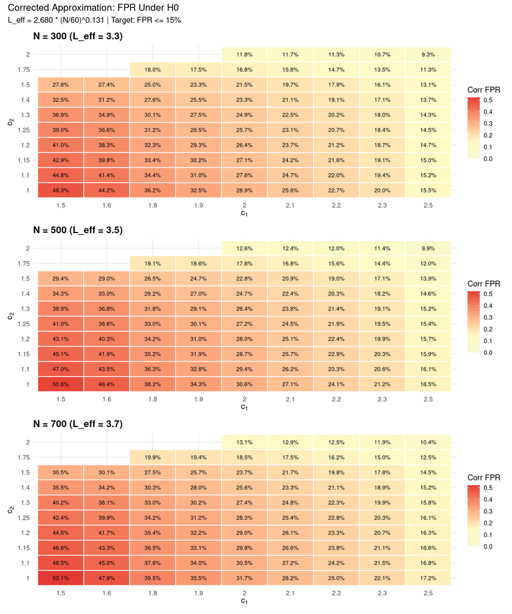

Corrected approximation FPR across the (c1,c2) grid. Only the region near the FPR boundary is relevant for threshold selection.

```r
# Subset to readable range (c1_heat, c2_heat from setup)
heat_sub <- full_dt[c1 %in% c1_heat & c2 %in% c2_heat]

heatmap_list <- lapply(N_target, function(N_val) {
  sub <- heat_sub[N == N_val]
  ggplot(sub, aes(x = factor(c1), y = factor(c2),
                  fill = FPR_corr)) +
    geom_tile(colour = "white", linewidth = 0.5) +
    geom_text(aes(label = sprintf("%.1f%%", 100 * FPR_corr)),
              size = 2.8, colour = "black") +
    scale_fill_gradient2(
      low = "#E8F5E9", mid = "#FFF9C4", high = "#E53935",
      midpoint = fpr_target,
      limits = c(0, max(heat_sub$FPR_corr, 0.30)),
      name = "Corr FPR"
    ) +
    labs(x = expression(c[1]), y = expression(c[2]),
         title = sprintf("N = %d (L_eff = %.1f)", N_val,
           C_fit * (N_val / n_min_val)^alpha_fit)) +
    theme_minimal(base_size = 11) +
    theme(plot.title = element_text(face = "bold"),
          axis.text = element_text(size = 9))
})

wrap_plots(heatmap_list, ncol = 1) +
  plot_annotation(
    title = "Corrected Approximation: FPR Under H0",
    subtitle = sprintf(
      "L_eff = %.3f * (N/%d)^%.3f | Target: FPR <= %.0f%%",
      C_fit, n_min_val, alpha_fit, 100 * fpr_target))
```

## 5.3 Pre-Select: Smallest $(c_1, c_2)$ Meeting the Target

For each $(c_1, c_2)$, the corrected FPR must be at most 15% at **every** target $N$. Since $L_{\text{eff}}$ grows with $N$, the binding constraint is at the largest $N$ ($= 700$).

We seek the **smallest $c_1$** that achieves the target, and for each $c_1$, the **smallest $c_2$** that suffices.

```r
# For each (c1,c2), compute corrected FPR at the most
# stringent N (largest, where L_eff is highest)
N_max <- max(N_target)
worst_case <- full_dt[N == N_max, .(c1, c2, FPR_corr)]

# Also collect FPR at all N for display
fpr_wide <- full_dt[, .(
  FPR_corr_worst = FPR_corr[N == N_max]
), by = .(c1, c2)]

# Merge with per-N values
for (N_val in N_target) {
  col_name <- sprintf("FPR_N%d", N_val)
  fpr_wide[[col_name]] <- full_dt[N == N_val,
    FPR_corr[match(paste(fpr_wide$c1, fpr_wide$c2),
                   paste(c1, c2))]]
}

# Identify pairs meeting the target
selected <- fpr_wide[FPR_corr_worst <= fpr_target]
setorder(selected, c1, c2)

cat(sprintf(
  "Pairs with corrected FPR <= %.0f%% at N=%d: %d of %d\n",
  100 * fpr_target, N_max, nrow(selected), nrow(fpr_wide)))
```

```
#> Pairs with corrected FPR <= 15% at N=700: 62 of 384
```

```r
# Frontier: for each c1, the minimum c2 that meets the target
frontier <- selected[, .(
  min_c2 = min(c2),
  FPR_at_min_c2 = FPR_corr_worst[which.min(c2)]
), by = c1]
setorder(frontier, c1)

if (nrow(frontier) > 0) {
  cat(sprintf("\nSmallest c1 achieving target: %.2f (with c2=%.2f)\n",
      frontier$c1[1], frontier$min_c2[1]))

  gt(frontier[, .(
    c1,
    `Min c2` = min_c2,
    `Corr FPR (worst N)` = sprintf("%.1f%%", 100 * FPR_at_min_c2)
  )]) |>
    tab_header(
      title = md(sprintf(
        "**Frontier: Minimum c2 for Each c1 (FPR <= %.0f%%)**",
        100 * fpr_target)),
      subtitle = sprintf(
        "Binding constraint at N=%d (L_eff=%.1f)",
        N_max, C_fit * (N_max / n_min_val)^alpha_fit)
    ) |>
    tab_style(style = cell_fill(color = "#E8F5E9"),
      locations = cells_body(rows = c1 == frontier$c1[1]))
} else {
  cat("No c1 values achieved the target.\n")
  cat("Consider relaxing fpr_target or increasing c1/c2 grid.\n")
}
```

```
#>
#> Smallest c1 achieving target: 2.00 (with c2=1.95)
```

Minimum c2 required for each c1 to achieve corrected FPR <= target at all N

**Frontier: Minimum c2 for Each c1 (FPR <= 15%)**

Binding constraint at N=700 (L_eff=3.7)

| c1 | Min c2 | Corr FPR (worst N) |
| --- | --- | --- |
| 2.00 | 1.95 | 14.2% |
| 2.05 | 1.95 | 14.1% |
| 2.10 | 1.90 | 14.8% |
| 2.15 | 1.90 | 14.4% |
| 2.20 | 1.85 | 14.8% |
| 2.25 | 1.80 | 15.0% |
| 2.30 | 1.75 | 15.0% |
| 2.35 | 1.70 | 14.9% |
| 2.40 | 1.65 | 14.7% |
| 2.45 | 1.55 | 14.9% |
| 2.50 | 1.45 | 14.8% |

## 5.4 Optimal Pair: Power Curve

The frontier identifies the **least restrictive** thresholds that still control FPR. We extract $(c_{1,\min}, c_{2,\min})$ — the smallest $c_1$ achieving the target, paired with its minimum $c_2$ — and plot the power curve.

**ImportantWhy the $L_{\text{eff}}$ correction is asymmetric**

The correction serves different roles under $H_0$ and $H_1$:

**Under $H_0$ (FPR):** every candidate subgroup is null, each with per-subgroup probability $P_1(\theta = 1)$ of falsely passing the screening and consistency criteria. The procedure evaluates $\sim L_{\text{eff}}$ approximately independent candidates, so the procedure-level FPR is

$$\text{FPR}_{\text{corr}} = 1 - (1 - P_1)^{L_{\text{eff}}}
\;\gg\; P_1$$

The correction is essential here — without it, the per-subgroup rate understates the procedure-level rate by a factor of $L_{\text{eff}}$.

$$\text{Power} \;\approx\; P_1(\theta^\dagger)
\qquad \text{(uncorrected)}$$

When `nsims_power > 0`, a targeted $H_1$ simulation is run at $\theta = 2$ for the optimal pair to spot-check $P_1$ accuracy at the effect size of interest.

```
#> === Optimal Pair: c1 = 2.00, c2 = 1.95 ===
#> Corrected FPR at this pair: 14.2% (target: 15%)
#>
#> --- Running 500 H1 sims at OR = 2.0 ---
#>   N =  300: Sim power = 13.0% (65/500) | L_eff = 3.31
#>   N =  500: Sim power = 23.8% (119/500) | L_eff = 3.54
#>   N =  700: Sim power = 27.0% (135/500) | L_eff = 3.70
#> Power simulation: 1.2 min
```

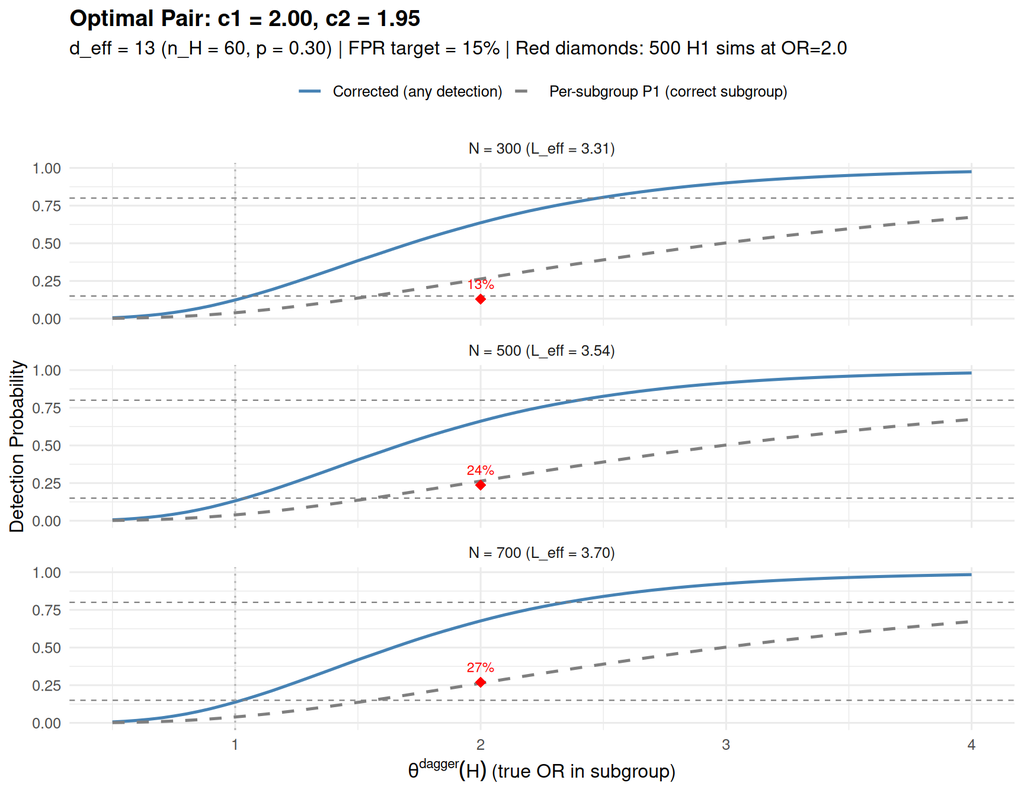

Power curve for optimal pair (c1=2.00, c2=1.95). Solid blue = corrected (any detection), dashed grey = per-subgroup P1 (correct subgroup), red diamonds = simulation.

```
#>
#> === Power at Key Effect Sizes ===
#> OR        N=300  (P1)  (corr)   (sim)  N=500  (P1)  (corr)   (sim)  N=700  (P1)  (corr)   (sim)
#> 1.00        3.9%   12.4%      -    3.9%   13.2%      -    3.9%   13.7%      -
#> 1.25        8.2%   24.6%      -    8.2%   26.0%      -    8.2%   27.0%      -
#> 1.50       13.7%   38.5%      -   13.7%   40.5%      -   13.7%   41.9%      -
#> 2.00       26.3%   63.6%   13.0%   26.3%   66.1%   23.8%   26.3%   67.7%   27.0%
#> 2.50       39.0%   80.5%      -   39.0%   82.6%      -   39.0%   83.9%      -
#> 3.00       50.3%   90.1%      -   50.3%   91.6%      -   50.3%   92.5%      -
```

```r
if (exists("frontier") && nrow(frontier) > 0) {

  c1_opt <- frontier$c1[1]
  c2_opt <- frontier$min_c2[1]

  cat(sprintf("=== Optimal Pair: c1 = %.2f, c2 = %.2f ===\n",
              c1_opt, c2_opt))
  cat(sprintf("Corrected FPR at this pair: %.1f%% (target: %.0f%%)\n",
              100 * frontier$FPR_at_min_c2[1], 100 * fpr_target))

  # ── Approximation power curve ──────────────────────────────
  d_ref <- round(d_eff_binary(n_min_val, p_event))
  or_seq <- seq(0.5, 4.0, by = 0.05)

  power_curves <- do.call(rbind, lapply(N_target, function(N_val) {
    L_eff <- C_fit * (N_val / n_min_val)^alpha_fit
    data.frame(
      OR = rep(or_seq, 2),
      Power = c(
        sapply(or_seq, function(or) {
          P1 <- p_detect(or, d_ref, c1_opt, c2_opt)
          1 - (1 - P1)^L_eff
        }),
        sapply(or_seq, function(or) {
          p_detect(or, d_ref, c1_opt, c2_opt)
        })
      ),
      Type = rep(c("Corrected (any detection)",
                   "Per-subgroup P1 (correct subgroup)"),
                 each = length(or_seq)),
      N = sprintf("N = %d (L_eff = %.2f)", N_val, L_eff)
    )
  }))

  # ── Targeted H1 simulation at theta_h1 ─────────────────────
  sim_power_points <- NULL
  if (nsims_power > 0) {
    cat(sprintf("\n--- Running %d H1 sims at OR = %.1f ---\n",
                nsims_power, theta_h1))
    t0_power <- proc.time()[3]

    # Reset workers before power simulation phase
    future::plan("sequential"); gc(verbose = FALSE)
    future::plan("multisession", workers = n_workers)

    sim_power_results <- do.call(rbind, lapply(N_target, function(N_val) {
      found_raw <- foreach(
        s = seq_len(nsims_power),
        .errorhandling = "pass",
        .options.future = list(
          packages = c("forestsearch", "data.table"),
          seed = TRUE)
      ) %dofuture% {
        future::plan("sequential")
        seed <- sim_seed + 100000L + (N_val * 1000L) + s
        df_h1 <- sim_binary_h1(N_val, seed)
        fs <- tryCatch(
          suppressWarnings(
            forestsearch(
              df.analysis = df_h1,
              confounders.name = confounders_name,
              outcome.name = "progressed", event.name = "progressed",
              treat.name = "treat", id.name = "id",
              outcome_type = "binary", effect_measure = "OR",
              adverse_outcome = TRUE,
              hr.threshold = c1_opt,
              hr.consistency = c2_opt,
              pconsistency.threshold = pcons, fs.splits = fs_splits,
              n.min = n_min_val, maxk = maxk_val,
              use_lasso = TRUE, use_grf = TRUE,
              use_twostage = TRUE,
              is.RCT = TRUE, seedit = seed,
              details = FALSE, quiet = TRUE, plot.sg = FALSE,
              parallel_args = list(plan = "sequential", workers = 1,
                                   show_message = FALSE)
            )
          ),
          error = function(e) NULL
        )
        found <- !is.null(fs) && !is.null(fs$sg.harm) &&
                 length(fs$sg.harm) > 0
        data.frame(sim = s, N = N_val,
                   any_found = as.integer(found))
      }
      res_df <- forestsearch:::collect_results(
        found_raw, label = sprintf("H1 power N=%d", N_val)
      )
      n_good <- if (!is.null(res_df)) nrow(res_df) else 0L
      sim_pwr <- if (n_good > 0) mean(res_df$any_found, na.rm = TRUE) else NA_real_
      L_eff <- C_fit * (N_val / n_min_val)^alpha_fit
      cat(sprintf("  N = %4d: Sim power = %.1f%% (%d/%d) | L_eff = %.2f\n",
                  N_val, 100 * sim_pwr,
                  if (n_good > 0) sum(res_df$any_found) else 0L,
                  n_good, L_eff))
      data.frame(
        OR = theta_h1, Power = sim_pwr,
        Type = "Simulation",
        N = sprintf("N = %d (L_eff = %.2f)", N_val, L_eff))
    }))

    sim_power_points <- sim_power_results
    timings$power <- proc.time()[3] - t0_power
    cat(sprintf("Power simulation: %.1f min\n",
                timings$power / 60))

    # Free workers after power phase
    future::plan("sequential"); gc(verbose = FALSE)
  } else {
    timings$power <- 0
  }

  # Ensure sequential mode before plotting/post-processing
  future::plan("sequential")

  # ── Plot ────────────────────────────────────────────────────
  p <- ggplot(power_curves, aes(x = OR, y = Power,
                                 linetype = Type, colour = Type)) +
    geom_line(linewidth = 0.9) +
    geom_hline(yintercept = c(fpr_target, 0.80),
               linetype = "dashed", colour = "grey50", linewidth = 0.4) +
    geom_vline(xintercept = 1.0, linetype = "dotted", colour = "grey70")

  if (!is.null(sim_power_points)) {
    p <- p +
      geom_point(data = sim_power_points,
                 aes(x = OR, y = Power),
                 colour = "red", size = 3, shape = 18,
                 inherit.aes = FALSE) +
      geom_text(data = sim_power_points,
                aes(x = OR, y = Power,
                    label = sprintf("%.0f%%", 100 * Power)),
                colour = "red", vjust = -1, size = 3,
                inherit.aes = FALSE)
  }

  p <- p +
    facet_wrap(~ N, ncol = 1) +
    scale_linetype_manual(values = c(
      "Corrected (any detection)" = "solid",
      "Per-subgroup P1 (correct subgroup)" = "dashed")) +
    scale_colour_manual(values = c(
      "Corrected (any detection)" = "steelblue",
      "Per-subgroup P1 (correct subgroup)" = "grey50")) +
    labs(x = expression(theta^dagger*(H) ~ "(true OR in subgroup)"),
         y = "Detection Probability",
         title = sprintf("Optimal Pair: c1 = %.2f, c2 = %.2f",
                          c1_opt, c2_opt),
         subtitle = sprintf(
           "d_eff = %d (n_H = %d, p = %.2f) | FPR target = %.0f%%%s",
           d_ref, n_min_val, p_event, 100 * fpr_target,
           if (nsims_power > 0)
             sprintf(" | Red diamonds: %d H1 sims at OR=%.1f",
                     nsims_power, theta_h1) else ""),
         linetype = NULL, colour = NULL) +
    theme_minimal(base_size = 12) +
    theme(legend.position = "top",
          plot.title = element_text(face = "bold"))
  print(p)

  # ── Power summary table ────────────────────────────────────
  cat("\n=== Power at Key Effect Sizes ===\n")
  header <- sprintf("%-8s", "OR")
  for (N_val in N_target) {
    header <- paste0(header, sprintf("  N=%-4d (P1)  (corr)", N_val))
    if (nsims_power > 0) header <- paste0(header, "   (sim)")
  }
  cat(header, "\n")

  for (or_val in c(1.0, 1.25, 1.50, theta_h1, 2.5, 3.0)) {
    cat(sprintf("%-8.2f", or_val))
    for (N_val in N_target) {
      L_eff <- C_fit * (N_val / n_min_val)^alpha_fit
      P1 <- p_detect(or_val, d_ref, c1_opt, c2_opt)
      P_corr <- 1 - (1 - P1)^L_eff
      cat(sprintf("  %5.1f%%  %5.1f%%", 100 * P1, 100 * P_corr))
      if (nsims_power > 0) {
        sp <- sim_power_points[sim_power_points$N ==
          sprintf("N = %d (L_eff = %.2f)", N_val, L_eff), ]
        if (nrow(sp) > 0 && abs(or_val - theta_h1) < 0.01) {
          cat(sprintf("  %5.1f%%", 100 * sp$Power[1]))
        } else {
          cat("      -")
        }
      }
    }
    cat("\n")
  }

} else {
  cat("No frontier found. Cannot compute optimal pair power curve.\n")
  cat("Consider expanding c1_grid/c2_grid or relaxing fpr_target.\n")
}
```

```r
if (exists("c1_opt")) {

  or_vals <- c(1.0, 1.25, 1.50, theta_h1, 2.5, 3.0)
  or_vals <- unique(sort(or_vals))

  power_tbl <- do.call(rbind, lapply(or_vals, function(or_val) {
    row <- data.frame(OR = or_val, stringsAsFactors = FALSE)
    for (N_val in N_target) {
      L_eff <- C_fit * (N_val / n_min_val)^alpha_fit
      P1 <- p_detect(or_val, d_ref, c1_opt, c2_opt)
      P_corr <- 1 - (1 - P1)^L_eff
      row[[sprintf("P1_N%d", N_val)]]   <- P1
      row[[sprintf("Corr_N%d", N_val)]] <- P_corr

      # Add simulation column if available
      if (!is.null(sim_power_points) &&
          abs(or_val - theta_h1) < 0.01) {
        sp <- sim_power_points[
          sim_power_points$N == sprintf("N = %d (L_eff = %.2f)",
                                         N_val, L_eff), ]
        row[[sprintf("Sim_N%d", N_val)]] <- if (nrow(sp) > 0)
          sp$Power[1] else NA_real_
      } else {
        row[[sprintf("Sim_N%d", N_val)]] <- NA_real_
      }
    }
    row
  }))

  # Build gt table with spanners per N
  tbl <- gt(power_tbl) |>
    fmt_percent(columns = -OR, decimals = 1) |>
    sub_missing(missing_text = "—") |>
    fmt_number(columns = OR, decimals = 2)

  for (N_val in N_target) {
    tbl <- tbl |>
      tab_spanner(
        label = sprintf("N = %d", N_val),
        columns = starts_with(c(sprintf("P1_N%d", N_val),
                                sprintf("Corr_N%d", N_val),
                                sprintf("Sim_N%d", N_val)))
      ) |>
      cols_label(
        !!sprintf("P1_N%d", N_val)   := "P1",
        !!sprintf("Corr_N%d", N_val) := "Corrected",
        !!sprintf("Sim_N%d", N_val)  := "Simulation"
      )
  }

  # Remove Simulation columns if no sims were run
  if (is.null(sim_power_points)) {
    sim_cols <- sprintf("Sim_N%d", N_target)
    tbl <- tbl |> cols_hide(columns = any_of(sim_cols))
  }

  tbl <- tbl |>
    tab_header(
      title = sprintf("Power: Optimal Pair (c1 = %.2f, c2 = %.2f)",
                      c1_opt, c2_opt),
      subtitle = sprintf(
        "d_eff = %d (n_H = %d, p = %.2f) | P1 = correct subgroup, Corrected = any detection%s",
        d_ref, n_min_val, p_event,
        if (!is.null(sim_power_points))
          sprintf(" | Sim: %d sims at OR = %.1f", nsims_power, theta_h1)
        else "")
    ) |>
    tab_style(
      style = cell_fill(color = "#E8F5E9"),
      locations = cells_body(
        columns = starts_with("P1_"),
        rows = OR == theta_h1)
    ) |>
    tab_style(
      style = cell_text(weight = "bold"),
      locations = cells_body(rows = OR == theta_h1)
    ) |>
    tab_source_note(sprintf(
      "P1 = per-subgroup detection (primary power measure) | Corrected = 1-(1-P1)^L_eff (overstates; see §5.4 callout) | OR = %.1f row highlighted",
      theta_h1))

  tbl
}
```

Power at optimal pair (c1 = 2.00, c2 = 1.95) by sample size and effect size

Power: Optimal Pair (c1 = 2.00, c2 = 1.95)

d_eff = 13 (n_H = 60, p = 0.30) | P1 = correct subgroup, Corrected = any detection | Sim: 500 sims at OR = 2.0

| OR | N = 300 P1 | N = 300 Corrected | N = 300 Simulation | N = 500 P1 | N = 500 Corrected | N = 500 Simulation | N = 700 P1 | N = 700 Corrected | N = 700 Simulation |
| --- | --- | --- | --- | --- | --- | --- | --- | --- | --- |
| 1.00 | 3.9% | 12.4% | — | 3.9% | 13.2% | — | 3.9% | 13.7% | — |
| 1.25 | 8.2% | 24.6% | — | 8.2% | 26.0% | — | 8.2% | 27.0% | — |
| 1.50 | 13.7% | 38.5% | — | 13.7% | 40.5% | — | 13.7% | 41.9% | — |
| 2.00 | 26.3% | 63.6% | 13.0% | 26.3% | 66.1% | 23.8% | 26.3% | 67.7% | 27.0% |
| 2.50 | 39.0% | 80.5% | — | 39.0% | 82.6% | — | 39.0% | 83.9% | — |
| 3.00 | 50.3% | 90.1% | — | 50.3% | 91.6% | — | 50.3% | 92.5% | — |

P1 = per-subgroup detection (primary power measure) | Corrected = 1-(1-P1)^L_eff (overstates; see §5.4 callout) | OR = 2.0 row highlighted

## 5.5 Full Selected Pairs Table

```r
if (nrow(selected) > 0) {
  display_cols <- c("c1", "c2", "FPR_corr_worst")
  for (N_val in N_target) {
    display_cols <- c(display_cols, sprintf("FPR_N%d", N_val))
  }

  display_dt <- selected[, ..display_cols]
  names(display_dt)[3] <- "Worst Case"
  for (N_val in N_target) {
    old_name <- sprintf("FPR_N%d", N_val)
    new_name <- sprintf("N=%d", N_val)
    names(display_dt)[names(display_dt) == old_name] <- new_name
  }

  # Format as percentages
  for (col in names(display_dt)[3:ncol(display_dt)]) {
    display_dt[[col]] <- sprintf("%.1f%%", 100 * display_dt[[col]])
  }

  gt(display_dt) |>
    tab_header(
      title = md(sprintf(
        "**All Pairs with Corrected FPR <= %.0f%%**",
        100 * fpr_target)),
      subtitle = "Sorted by c1 (ascending), then c2 (ascending)"
    ) |>
    tab_spanner(
      label = "Corrected FPR by N",
      columns = 4:ncol(display_dt)
    ) |>
    tab_source_note(
      "Worst Case = max corrected FPR across N values"
    )
} else {
  cat("No pairs met the target.\n")
}
```

All pairs meeting the corrected FPR target, sorted by c1 then c2 (smallest first)

**All Pairs with Corrected FPR <= 15%**

Sorted by c1 (ascending), then c2 (ascending)

| c1 | c2 | Worst Case | Corrected FPR by N N=300 | Corrected FPR by N N=500 | Corrected FPR by N N=700 |
| --- | --- | --- | --- | --- | --- |
| 2.00 | 1.95 | 14.2% | 12.8% | 13.6% | 14.2% |
| 2.00 | 2.00 | 13.1% | 11.8% | 12.6% | 13.1% |
| 2.05 | 1.95 | 14.1% | 12.7% | 13.5% | 14.1% |
| 2.05 | 2.00 | 13.1% | 11.8% | 12.5% | 13.1% |
| 2.10 | 1.90 | 14.8% | 13.3% | 14.2% | 14.8% |
| 2.10 | 1.95 | 13.8% | 12.5% | 13.3% | 13.8% |
| 2.10 | 2.00 | 12.9% | 11.7% | 12.4% | 12.9% |
| 2.15 | 1.90 | 14.4% | 13.0% | 13.8% | 14.4% |
| 2.15 | 1.95 | 13.6% | 12.2% | 13.0% | 13.6% |
| 2.15 | 2.00 | 12.7% | 11.5% | 12.2% | 12.7% |
| 2.20 | 1.85 | 14.8% | 13.3% | 14.2% | 14.8% |
| 2.20 | 1.90 | 14.0% | 12.7% | 13.5% | 14.0% |
| 2.20 | 1.95 | 13.3% | 12.0% | 12.7% | 13.3% |
| 2.20 | 2.00 | 12.5% | 11.3% | 12.0% | 12.5% |
| 2.25 | 1.80 | 15.0% | 13.5% | 14.4% | 15.0% |
| 2.25 | 1.85 | 14.3% | 12.9% | 13.7% | 14.3% |
| 2.25 | 1.90 | 13.6% | 12.2% | 13.0% | 13.6% |
| 2.25 | 1.95 | 12.9% | 11.6% | 12.4% | 12.9% |
| 2.25 | 2.00 | 12.2% | 11.0% | 11.7% | 12.2% |
| 2.30 | 1.75 | 15.0% | 13.5% | 14.4% | 15.0% |
| 2.30 | 1.80 | 14.4% | 13.0% | 13.8% | 14.4% |
| 2.30 | 1.85 | 13.8% | 12.4% | 13.2% | 13.8% |
| 2.30 | 1.90 | 13.1% | 11.9% | 12.6% | 13.1% |
| 2.30 | 1.95 | 12.5% | 11.3% | 12.0% | 12.5% |
| 2.30 | 2.00 | 11.9% | 10.7% | 11.4% | 11.9% |
| 2.35 | 1.70 | 14.9% | 13.5% | 14.3% | 14.9% |
| 2.35 | 1.75 | 14.4% | 12.9% | 13.8% | 14.4% |
| 2.35 | 1.80 | 13.8% | 12.5% | 13.3% | 13.8% |
| 2.35 | 1.85 | 13.3% | 12.0% | 12.7% | 13.3% |
| 2.35 | 1.90 | 12.7% | 11.4% | 12.2% | 12.7% |
| 2.35 | 1.95 | 12.1% | 10.9% | 11.6% | 12.1% |
| 2.35 | 2.00 | 11.5% | 10.4% | 11.1% | 11.5% |
| 2.40 | 1.65 | 14.7% | 13.3% | 14.2% | 14.7% |
| 2.40 | 1.70 | 14.2% | 12.8% | 13.7% | 14.2% |
| 2.40 | 1.75 | 13.7% | 12.4% | 13.2% | 13.7% |
| 2.40 | 1.80 | 13.3% | 11.9% | 12.7% | 13.3% |
| 2.40 | 1.85 | 12.7% | 11.5% | 12.2% | 12.7% |
| 2.40 | 1.90 | 12.2% | 11.0% | 11.7% | 12.2% |
| 2.40 | 1.95 | 11.7% | 10.5% | 11.2% | 11.7% |
| 2.40 | 2.00 | 11.2% | 10.0% | 10.7% | 11.2% |
| 2.45 | 1.55 | 14.9% | 13.4% | 14.3% | 14.9% |
| 2.45 | 1.60 | 14.5% | 13.0% | 13.9% | 14.5% |
| 2.45 | 1.65 | 14.0% | 12.7% | 13.5% | 14.0% |
| 2.45 | 1.70 | 13.6% | 12.2% | 13.0% | 13.6% |
| 2.45 | 1.75 | 13.1% | 11.8% | 12.6% | 13.1% |
| 2.45 | 1.80 | 12.7% | 11.4% | 12.2% | 12.7% |
| 2.45 | 1.85 | 12.2% | 11.0% | 11.7% | 12.2% |
| 2.45 | 1.90 | 11.7% | 10.6% | 11.2% | 11.7% |
| 2.45 | 1.95 | 11.2% | 10.1% | 10.8% | 11.2% |
| 2.45 | 2.00 | 10.7% | 9.7% | 10.3% | 10.7% |
| 2.50 | 1.45 | 14.8% | 13.4% | 14.2% | 14.8% |
| 2.50 | 1.50 | 14.5% | 13.1% | 13.9% | 14.5% |
| 2.50 | 1.55 | 14.1% | 12.7% | 13.6% | 14.1% |
| 2.50 | 1.60 | 13.7% | 12.4% | 13.2% | 13.7% |
| 2.50 | 1.65 | 13.3% | 12.0% | 12.8% | 13.3% |
| 2.50 | 1.70 | 12.9% | 11.7% | 12.4% | 12.9% |
| 2.50 | 1.75 | 12.5% | 11.3% | 12.0% | 12.5% |
| 2.50 | 1.80 | 12.1% | 10.9% | 11.6% | 12.1% |
| 2.50 | 1.85 | 11.7% | 10.5% | 11.2% | 11.7% |
| 2.50 | 1.90 | 11.3% | 10.1% | 10.8% | 11.3% |
| 2.50 | 1.95 | 10.8% | 9.7% | 10.4% | 10.8% |
| 2.50 | 2.00 | 10.4% | 9.3% | 9.9% | 10.4% |

Worst Case = max corrected FPR across N values

## 5.6 Boundary Pairs (Near the Target)

Include pairs slightly above the target to map the transition and provide simulation candidates.

```r
boundary <- fpr_wide[FPR_corr_worst > fpr_target &
                      FPR_corr_worst <= fpr_target + 0.05]

sim_candidates <- rbind(
  selected[, .(c1, c2, FPR_corr_worst, region = "selected")],
  boundary[, .(c1, c2, FPR_corr_worst, region = "boundary")]
)
setorder(sim_candidates, c1, c2)

# Thin to manageable count (max_pairs from setup)
if (nrow(sim_candidates) > max_pairs) {
  n_sel <- sum(sim_candidates$region == "selected")
  n_boundary_keep <- max(max_pairs - n_sel, 5L)
  sim_candidates <- rbind(
    sim_candidates[region == "selected"],
    sim_candidates[region == "boundary"][
      seq(1, .N, length.out = min(.N, n_boundary_keep))]
  )
}

cat(sprintf(
  "Simulation candidates: %d selected + %d boundary = %d total\n",
  sum(sim_candidates$region == "selected"),
  sum(sim_candidates$region == "boundary"),
  nrow(sim_candidates)))
```

```
#> Simulation candidates: 62 selected + 5 boundary = 67 total
```

# 6 Part III: Simulation Validation

Set `nsims_val = 0` in the setup chunk to skip validation and rely entirely on the corrected approximation. Increase `nsims_val` (e.g., 500) for production-quality validation.

```r
run_validation <- nsims_val > 0

if (run_validation) {
  t0 <- proc.time()[3]

  # Only validate the frontier pairs: the minimum c2 for each c1
  # that achieves FPR_corr <= target.  At most 10 pairs.
  if (exists("frontier") && nrow(frontier) > 0) {
    val_candidates <- frontier[seq_len(min(10, nrow(frontier))),
                                .(c1, c2 = min_c2, FPR_corr = FPR_at_min_c2)]
  } else {
    val_candidates <- sim_candidates[region == "selected",
                                      .(c1, c2, FPR_corr = FPR_corr_worst)]
    if (nrow(val_candidates) > 10)
      val_candidates <- val_candidates[seq_len(10)]
  }

  cat(sprintf(
    "Validating %d frontier pairs (min c2 per c1, FPR_corr <= %.0f%%)\n",
    nrow(val_candidates), 100 * fpr_target))

  if (nrow(val_candidates) == 0) {
    warning("No candidate pairs to validate — skipping validation phase.")
    run_validation <- FALSE
    timings$validation <- 0
    val_results <- NULL
  } else {

  for (r in seq_len(nrow(val_candidates))) {
    cat(sprintf("  c1=%.2f, c2=%.2f (corr FPR=%.1f%%)\n",
                val_candidates$c1[r], val_candidates$c2[r],
                100 * val_candidates$FPR_corr[r]))
  }

  # Build task list
  val_tasks <- do.call(rbind, lapply(N_target, function(N_val) {
    do.call(rbind, lapply(seq_len(nrow(val_candidates)), function(g) {
      data.frame(
        N = N_val,
        sim = seq_len(nsims_val),
        c1 = val_candidates$c1[g],
        c2 = val_candidates$c2[g],
        stringsAsFactors = FALSE
      )
    }))
  }))

  cat(sprintf(
    "Running %d validation tasks (%d pairs x %d N x %d sims)...\n",
    nrow(val_tasks), nrow(val_candidates),
    length(N_target), nsims_val))

  # Reset workers before validation phase
  future::plan("sequential"); gc(verbose = FALSE)
  future::plan("multisession", workers = n_workers)

  val_results <- foreach(
    i = seq_len(nrow(val_tasks)),
    .errorhandling = "pass",
    .options.future = list(
      packages = c("forestsearch", "data.table"), seed = TRUE)
  ) %dofuture% {
    future::plan("sequential")
    N_val  <- val_tasks$N[i]
    sim_id <- val_tasks$sim[i]
    c1_val <- val_tasks$c1[i]
    c2_val <- val_tasks$c2[i]

    seed <- sim_seed + 200000L + (N_val * 1000L) + sim_id
    df_null <- sim_binary_null(N_val, seed)

    fs <- tryCatch(
      suppressWarnings(
        forestsearch(
          df.analysis = df_null,
          confounders.name = confounders_name,
          outcome.name = "progressed", event.name = "progressed",
          treat.name = "treat", id.name = "id",
          outcome_type = "binary", effect_measure = "OR",
          adverse_outcome = TRUE,
          hr.threshold = c1_val, hr.consistency = c2_val,
          pconsistency.threshold = pcons, fs.splits = fs_splits,
          n.min = n_min_val, maxk = maxk_val,
          use_lasso = TRUE, use_grf = TRUE,
          use_twostage = TRUE,
          is.RCT = TRUE, seedit = seed,
          details = FALSE, quiet = TRUE, plot.sg = FALSE,
          parallel_args = list(plan = "sequential", workers = 1,
                               show_message = FALSE)
        )
      ),
      error = function(e) NULL
    )

    found <- !is.null(fs) && !is.null(fs$sg.harm) &&
             length(fs$sg.harm) > 0
    data.table(N = N_val, sim = sim_id,
               c1 = c1_val, c2 = c2_val,
               any_found = as.integer(found))
  }

  # ── Post-hoc error collection ──────────────────────────────────
  val_results <- forestsearch:::collect_results(val_results, label = "Validation")
  n_expected_val <- nrow(val_tasks)
  n_received_val <- if (is.null(val_results)) 0L else nrow(val_results)

  timings$validation <- proc.time()[3] - t0
  cat(sprintf("Validation: %.1f min | %d/%d results\n",
      timings$validation / 60, n_received_val, n_expected_val))

  }  # end if (nrow(val_candidates) > 0)

} else {
  timings$validation <- 0
  val_results <- NULL
  cat("Validation skipped (nsims_val = 0).\n")
  cat("Threshold selection based on corrected approximation only.\n")
}
```

```
#> Validating 10 frontier pairs (min c2 per c1, FPR_corr <= 15%)
#>   c1=2.00, c2=1.95 (corr FPR=14.2%)
#>   c1=2.05, c2=1.95 (corr FPR=14.1%)
#>   c1=2.10, c2=1.90 (corr FPR=14.8%)
#>   c1=2.15, c2=1.90 (corr FPR=14.4%)
#>   c1=2.20, c2=1.85 (corr FPR=14.8%)
#>   c1=2.25, c2=1.80 (corr FPR=15.0%)
#>   c1=2.30, c2=1.75 (corr FPR=15.0%)
#>   c1=2.35, c2=1.70 (corr FPR=14.9%)
#>   c1=2.40, c2=1.65 (corr FPR=14.7%)
#>   c1=2.45, c2=1.55 (corr FPR=14.9%)
#> Running 30000 validation tasks (10 pairs x 3 N x 1000 sims)...
#> Validation: 14.1 min | 30000/30000 results
```

```r
# Free workers before sequential post-processing
future::plan("sequential"); gc(verbose = FALSE)
```

```
#>           used  (Mb) gc trigger  (Mb) max used  (Mb)
#> Ncells 3106123 165.9    4787295 255.7  4787295 255.7
#> Vcells 5703291  43.6   12255594  93.6 12255594  93.6
```

# 7 Part IV: Results

```r
if (run_validation) {
  val_dt <- data.table(val_results)
  val_fpr <- val_dt[, .(
    Sim_FPR = mean(any_found, na.rm = TRUE),
    n_found = sum(any_found, na.rm = TRUE),
    n_sims = .N
  ), by = .(N, c1, c2)]

  # Merge with approximation
  val_fpr[, n_H := n_min_val]
  val_fpr[, d_eff := d_eff_binary(n_H, p_event)]
  val_fpr[, P1 := mapply(function(d, c1v, c2v) {
    p_detect(1.0, d, c1v, c2v)
  }, d_eff, c1, c2)]
  val_fpr[, L_eff_N := C_fit * (N / n_min_val)^alpha_fit]
  val_fpr[, FPR_corr := 1 - (1 - P1)^L_eff_N]

  # Assign region: validated pairs come from frontier (selected by
  # construction).  Try to enrich from sim_candidates; default to
  # "frontier" for any pair not found there.
  if (exists("sim_candidates") && nrow(sim_candidates) > 0) {
    val_fpr <- merge(val_fpr,
      sim_candidates[, .(c1, c2, region)],
      by = c("c1", "c2"), all.x = TRUE)
    val_fpr[is.na(region), region := "frontier"]
  } else {
    val_fpr[, region := "frontier"]
  }

} else {
  val_dt <- NULL
  val_fpr <- NULL
  cat("No simulation results (nsims_val = 0).\n")
  cat("Results below are based on the corrected approximation only.\n")
}
```

## 7.1 Validation Table

```r
if (run_validation) {
  # CI under H0: FPR_corr is the truth
  val_fpr[, CI_lower := pmax(0, FPR_corr - 1.96 * sqrt(
    FPR_corr * (1 - FPR_corr) / n_sims))]
  val_fpr[, CI_upper := pmin(1, FPR_corr + 1.96 * sqrt(
    FPR_corr * (1 - FPR_corr) / n_sims))]
  val_fpr[, in_CI := Sim_FPR >= CI_lower & Sim_FPR <= CI_upper]

  tbl_val_out <- gt(val_fpr[, .(N, c1, c2,
    `Corr FPR` = sprintf("%.1f%%", 100 * FPR_corr),
    `95% CI` = sprintf("[%.1f%%, %.1f%%]",
      100 * CI_lower, 100 * CI_upper),
    `Sim FPR` = sprintf("%.1f%% (%d/%d)",
      100 * Sim_FPR, n_found, n_sims),
    `Sim/Corr` = round(Sim_FPR / pmax(FPR_corr, 0.001), 2),
    `In CI` = ifelse(in_CI, "Yes", "No")
  )]) |>
    tab_header(
      title = md("**Simulation Validation of Selected Pairs**"),
      subtitle = sprintf(
        "%d sims/config | L_eff = %.3f * (N/%d)^%.3f",
        nsims_val, C_fit, n_min_val, alpha_fit)
    )
  # Dynamic row groups for each N (reversed so largest appears first)
  for (n_val in rev(sort(unique(val_fpr$N)))) {
    tbl_val_out <- tbl_val_out |>
      tab_row_group(label = sprintf("N = %d", n_val),
                    rows = N == n_val)
  }
  tbl_val_out |>
    tab_style(style = cell_fill(color = "#E8F5E9"),
      locations = cells_body(columns = `In CI`,
        rows = `In CI` == "Yes")) |>
    tab_style(style = cell_fill(color = "#FFEBEE"),
      locations = cells_body(columns = `In CI`,
        rows = `In CI` == "No")) |>
    tab_source_note(paste(
      "95% CI: expected range of Sim FPR if Corr FPR is the true rate.",
      sprintf("Green = Sim FPR within CI; %d sims per config.",
              nsims_val)))
} else {
  cat("Validation table skipped (nsims_val = 0).\n")
}
```

Simulated FPR vs corrected approximation for pre-selected pairs.

**Simulation Validation of Selected Pairs**

1000 sims/config | L_eff = 2.680 * (N/60)^0.131

| N | c1 | c2 | Corr FPR | 95% CI | Sim FPR | Sim/Corr | In CI |
| --- | --- | --- | --- | --- | --- | --- | --- |
| N = 300 |  |  |  |  |  |  |  |
| 300 | 2.00 | 1.95 | 12.8% | [10.7%, 14.9%] | 4.3% (43/1000) | 0.34 | No |
| 300 | 2.05 | 1.95 | 12.7% | [10.6%, 14.7%] | 4.3% (43/1000) | 0.34 | No |
| 300 | 2.10 | 1.90 | 13.3% | [11.2%, 15.4%] | 4.8% (48/1000) | 0.36 | No |
| 300 | 2.15 | 1.90 | 13.0% | [10.9%, 15.1%] | 4.8% (48/1000) | 0.37 | No |
| 300 | 2.20 | 1.85 | 13.3% | [11.2%, 15.5%] | 5.3% (53/1000) | 0.40 | No |
| 300 | 2.25 | 1.80 | 13.5% | [11.4%, 15.6%] | 6.0% (60/1000) | 0.44 | No |
| 300 | 2.30 | 1.75 | 13.5% | [11.4%, 15.6%] | 6.5% (65/1000) | 0.48 | No |
| 300 | 2.35 | 1.70 | 13.5% | [11.3%, 15.6%] | 7.6% (76/1000) | 0.56 | No |
| 300 | 2.40 | 1.65 | 13.3% | [11.2%, 15.4%] | 8.8% (88/1000) | 0.66 | No |
| 300 | 2.45 | 1.55 | 13.4% | [11.3%, 15.5%] | 11.9% (119/1000) | 0.89 | Yes |
| N = 500 |  |  |  |  |  |  |  |
| 500 | 2.00 | 1.95 | 13.6% | [11.5%, 15.8%] | 4.2% (42/1000) | 0.31 | No |
| 500 | 2.05 | 1.95 | 13.5% | [11.4%, 15.6%] | 4.2% (42/1000) | 0.31 | No |
| 500 | 2.10 | 1.90 | 14.2% | [12.0%, 16.3%] | 4.7% (47/1000) | 0.33 | No |
| 500 | 2.15 | 1.90 | 13.8% | [11.7%, 16.0%] | 4.7% (47/1000) | 0.34 | No |
| 500 | 2.20 | 1.85 | 14.2% | [12.0%, 16.4%] | 5.6% (56/1000) | 0.39 | No |
| 500 | 2.25 | 1.80 | 14.4% | [12.2%, 16.5%] | 6.6% (66/1000) | 0.46 | No |
| 500 | 2.30 | 1.75 | 14.4% | [12.2%, 16.5%] | 7.3% (73/1000) | 0.51 | No |
| 500 | 2.35 | 1.70 | 14.3% | [12.2%, 16.5%] | 8.5% (85/1000) | 0.59 | No |
| 500 | 2.40 | 1.65 | 14.2% | [12.0%, 16.3%] | 9.4% (94/1000) | 0.66 | No |
| 500 | 2.45 | 1.55 | 14.3% | [12.1%, 16.5%] | 14.2% (142/1000) | 0.99 | Yes |
| N = 700 |  |  |  |  |  |  |  |
| 700 | 2.00 | 1.95 | 14.2% | [12.0%, 16.4%] | 2.6% (26/1000) | 0.18 | No |
| 700 | 2.05 | 1.95 | 14.1% | [11.9%, 16.2%] | 2.6% (26/1000) | 0.18 | No |
| 700 | 2.10 | 1.90 | 14.8% | [12.6%, 17.0%] | 3.1% (31/1000) | 0.21 | No |
| 700 | 2.15 | 1.90 | 14.4% | [12.2%, 16.6%] | 3.1% (31/1000) | 0.21 | No |
| 700 | 2.20 | 1.85 | 14.8% | [12.6%, 17.0%] | 4.0% (40/1000) | 0.27 | No |
| 700 | 2.25 | 1.80 | 15.0% | [12.8%, 17.2%] | 4.8% (48/1000) | 0.32 | No |
| 700 | 2.30 | 1.75 | 15.0% | [12.8%, 17.2%] | 5.5% (55/1000) | 0.37 | No |
| 700 | 2.35 | 1.70 | 14.9% | [12.7%, 17.1%] | 6.6% (66/1000) | 0.44 | No |
| 700 | 2.40 | 1.65 | 14.7% | [12.5%, 16.9%] | 8.1% (81/1000) | 0.55 | No |
| 700 | 2.45 | 1.55 | 14.9% | [12.7%, 17.1%] | 11.6% (116/1000) | 0.78 | No |

95% CI: expected range of Sim FPR if Corr FPR is the true rate. Green = Sim FPR within CI; 1000 sims per config.

## 7.2 Validation Scatter

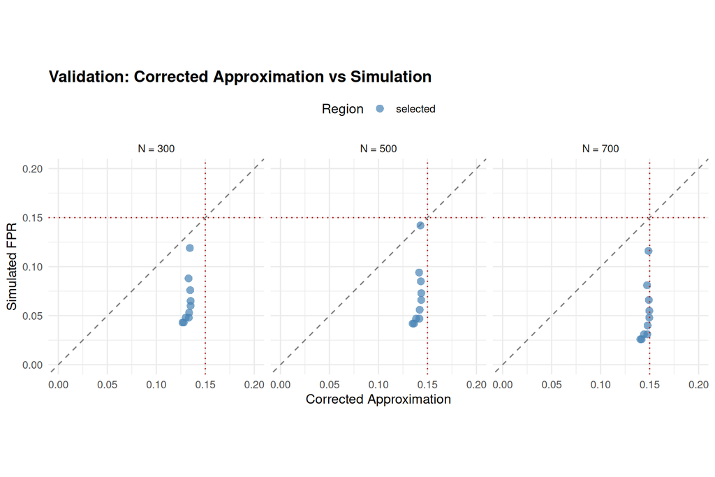

```r
if (run_validation) {
  print(
    ggplot(val_fpr, aes(x = FPR_corr, y = Sim_FPR)) +
      geom_abline(slope = 1, intercept = 0, linetype = "dashed",
                  colour = "grey50") +
      geom_point(aes(colour = region, shape = region), size = 3,
                 alpha = 0.7) +
      geom_hline(yintercept = fpr_target, linetype = "dotted",
                 colour = "firebrick") +
      geom_vline(xintercept = fpr_target, linetype = "dotted",
                 colour = "firebrick") +
      scale_colour_manual(
        values = c("selected" = "steelblue",
                   "boundary" = "orange",
                   "frontier" = "steelblue")) +
      facet_wrap(~ paste("N =", N)) +
      coord_equal(
        xlim = c(0, max(val_fpr$FPR_corr, 0.20)),
        ylim = c(0, max(val_fpr$Sim_FPR, 0.20))) +
      labs(x = "Corrected Approximation",
           y = "Simulated FPR",
           title = "Validation: Corrected Approximation vs Simulation",
           colour = "Region", shape = "Region") +
      theme_minimal(base_size = 12) +
      theme(legend.position = "top",
            plot.title = element_text(face = "bold"))
  )
} else {
  cat("Scatter plot skipped (nsims_val = 0).\n")
}
```

## 7.3 Confirmed Acceptable Pairs

```r
if (run_validation) {
  # Pairs where both approximation AND simulation agree
  confirmed <- val_fpr[Sim_FPR <= fpr_target &
                        FPR_corr <= fpr_target]
  setorder(confirmed, N, -Sim_FPR)

  if (nrow(confirmed) > 0) {
    tbl_conf <- gt(confirmed[, .(N, c1, c2,
      `Corr FPR` = sprintf("%.1f%%", 100 * FPR_corr),
      `95% CI` = sprintf("[%.1f%%, %.1f%%]",
        100 * CI_lower, 100 * CI_upper),
      `Sim FPR` = sprintf("%.1f%%", 100 * Sim_FPR),
      `Sim/Corr` = round(Sim_FPR / pmax(FPR_corr, 0.001), 2),
      `In CI` = ifelse(in_CI, "Yes", "No")
    )]) |>
      tab_header(
        title = md(sprintf(
          "**Confirmed Pairs: FPR <= %.0f%% (Approx AND Sim)**",
          100 * fpr_target)),
        subtitle = sprintf("%d sims per config", nsims_val)
      )
    for (n_val in rev(sort(unique(confirmed$N)))) {
      tbl_conf <- tbl_conf |>
        tab_row_group(label = sprintf("N = %d", n_val),
                      rows = N == n_val)
    }
    tbl_conf |>
      tab_style(style = cell_fill(color = "#E8F5E9"),
        locations = cells_body(columns = `In CI`,
          rows = `In CI` == "Yes")) |>
      tab_style(style = cell_fill(color = "#FFEBEE"),
        locations = cells_body(columns = `In CI`,
          rows = `In CI` == "No")) |>
      tab_source_note(paste(
        "95% CI bounds treat Corr FPR as the true rate.",
        "'In CI' = simulated FPR falls within expected range."))
  } else {
    cat("No pairs confirmed at this sim count.\n")
    cat("Consider increasing nsims_val.\n")
  }

} else {
  # No simulation: "confirmed" = approximation-selected only
  confirmed <- selected
  confirmed[, N := NA_integer_]

  cat("No simulation validation (nsims_val = 0).\n")
  cat(sprintf(
    "Approximation-selected pairs (corrected FPR <= %.0f%%): %d\n",
    100 * fpr_target, nrow(confirmed)))
  cat("Re-render with nsims_val > 0 to validate by simulation.\n")
}
```

Confirmed acceptable pairs

**Confirmed Pairs: FPR <= 15% (Approx AND Sim)**

1000 sims per config

| N | c1 | c2 | Corr FPR | 95% CI | Sim FPR | Sim/Corr | In CI |
| --- | --- | --- | --- | --- | --- | --- | --- |
| N = 300 |  |  |  |  |  |  |  |
| 300 | 2.45 | 1.55 | 13.4% | [11.3%, 15.5%] | 11.9% | 0.89 | Yes |
| 300 | 2.40 | 1.65 | 13.3% | [11.2%, 15.4%] | 8.8% | 0.66 | No |
| 300 | 2.35 | 1.70 | 13.5% | [11.3%, 15.6%] | 7.6% | 0.56 | No |
| 300 | 2.30 | 1.75 | 13.5% | [11.4%, 15.6%] | 6.5% | 0.48 | No |
| 300 | 2.25 | 1.80 | 13.5% | [11.4%, 15.6%] | 6.0% | 0.44 | No |
| 300 | 2.20 | 1.85 | 13.3% | [11.2%, 15.5%] | 5.3% | 0.40 | No |
| 300 | 2.10 | 1.90 | 13.3% | [11.2%, 15.4%] | 4.8% | 0.36 | No |
| 300 | 2.15 | 1.90 | 13.0% | [10.9%, 15.1%] | 4.8% | 0.37 | No |
| 300 | 2.00 | 1.95 | 12.8% | [10.7%, 14.9%] | 4.3% | 0.34 | No |
| 300 | 2.05 | 1.95 | 12.7% | [10.6%, 14.7%] | 4.3% | 0.34 | No |
| N = 500 |  |  |  |  |  |  |  |
| 500 | 2.45 | 1.55 | 14.3% | [12.1%, 16.5%] | 14.2% | 0.99 | Yes |
| 500 | 2.40 | 1.65 | 14.2% | [12.0%, 16.3%] | 9.4% | 0.66 | No |
| 500 | 2.35 | 1.70 | 14.3% | [12.2%, 16.5%] | 8.5% | 0.59 | No |
| 500 | 2.30 | 1.75 | 14.4% | [12.2%, 16.5%] | 7.3% | 0.51 | No |
| 500 | 2.25 | 1.80 | 14.4% | [12.2%, 16.5%] | 6.6% | 0.46 | No |
| 500 | 2.20 | 1.85 | 14.2% | [12.0%, 16.4%] | 5.6% | 0.39 | No |
| 500 | 2.10 | 1.90 | 14.2% | [12.0%, 16.3%] | 4.7% | 0.33 | No |
| 500 | 2.15 | 1.90 | 13.8% | [11.7%, 16.0%] | 4.7% | 0.34 | No |
| 500 | 2.00 | 1.95 | 13.6% | [11.5%, 15.8%] | 4.2% | 0.31 | No |
| 500 | 2.05 | 1.95 | 13.5% | [11.4%, 15.6%] | 4.2% | 0.31 | No |
| N = 700 |  |  |  |  |  |  |  |
| 700 | 2.45 | 1.55 | 14.9% | [12.7%, 17.1%] | 11.6% | 0.78 | No |
| 700 | 2.40 | 1.65 | 14.7% | [12.5%, 16.9%] | 8.1% | 0.55 | No |
| 700 | 2.35 | 1.70 | 14.9% | [12.7%, 17.1%] | 6.6% | 0.44 | No |
| 700 | 2.30 | 1.75 | 15.0% | [12.8%, 17.2%] | 5.5% | 0.37 | No |
| 700 | 2.25 | 1.80 | 15.0% | [12.8%, 17.2%] | 4.8% | 0.32 | No |
| 700 | 2.20 | 1.85 | 14.8% | [12.6%, 17.0%] | 4.0% | 0.27 | No |
| 700 | 2.10 | 1.90 | 14.8% | [12.6%, 17.0%] | 3.1% | 0.21 | No |
| 700 | 2.15 | 1.90 | 14.4% | [12.2%, 16.6%] | 3.1% | 0.21 | No |
| 700 | 2.00 | 1.95 | 14.2% | [12.0%, 16.4%] | 2.6% | 0.18 | No |
| 700 | 2.05 | 1.95 | 14.1% | [11.9%, 16.2%] | 2.6% | 0.18 | No |

95% CI bounds treat Corr FPR as the true rate. 'In CI' = simulated FPR falls within expected range.

# 8 Part V: Save Results

```r
results_bundle <- list(
  # Parameters
  params = list(
    nsims_val = nsims_val, sim_seed = sim_seed,
    n_workers = n_workers,
    C_fit = C_fit, alpha_fit = alpha_fit,
    recalibrate = recalibrate,
    n_sims_recal = n_sims_recal,
    fpr_target = fpr_target,
    n_min_val = n_min_val, p_event = p_event,
    p_harm = p_harm, pcons = pcons,
    N_target = N_target,
    c1_grid = c1_grid, c2_grid = c2_grid,
    timestamp = Sys.time()
  ),

  # L_eff calibration object and raw data
  # (If recalibrate = FALSE, stores prior values only.
  #  If TRUE, stores the full calibration data for
  #  reproducing the fit.)
  leff_calibration = if (exists("leff_cal")) leff_cal else
    list(C = C_fit, alpha = alpha_fit,
         n_min = n_min_val, source = "prior"),
  leff_raw_data = if (exists("cal_df")) cal_df else NULL,

  # Approximation grid (all pairs, all N)
  approx_grid = full_dt,

  # Pre-selected candidates
  sim_candidates = sim_candidates,

  # Frontier: minimum c2 per c1 achieving corrected FPR target
  frontier = if (exists("frontier")) frontier else NULL,

  # Raw simulation results (per-replicate)
  val_results_raw = val_dt,

  # Aggregated FPR by (N, c1, c2)
  val_fpr = val_fpr,

  # Confirmed acceptable pairs
  confirmed = if (exists("confirmed")) confirmed else NULL,

  # Timings
  timings = timings
)

if (!is.null(output_dir)) {
  if (!dir.exists(output_dir)) dir.create(output_dir,
                                           recursive = TRUE)
  rds_path <- file.path(output_dir,
    sprintf("binary_null_search_%s.rds",
            format(Sys.Date(), "%Y%m%d")))
  saveRDS(results_bundle, rds_path)
  cat(sprintf("Results saved to: %s\n", rds_path))
  cat(sprintf("  Size: %.1f KB\n", file.size(rds_path) / 1024))
} else {
  cat("Saving skipped (output_dir = NULL)\n")
}
```

```
#> Results saved to: ../_data/binary_null_search_20260416.rds
#>   Size: 26.8 KB
```

## 8.1 How to Reload and Extend

```r
# Load the most recent results bundle
res <- readRDS(latest_rds("binary_null_search"))

# Access components
res$params$C_fit           # L_eff parameters
res$params$alpha_fit
res$leff_calibration       # Full calibration object (or prior)
res$leff_raw_data          # Raw calibration data (if recalibrated)
res$approx_grid            # Full approximation grid
res$val_fpr                # Simulation results by (N, c1, c2)
res$confirmed              # Confirmed pairs

# Re-run with more sims: change nsims_val in setup and re-render.
# The approximation selection is instant; only validation re-runs.

# Use saved calibration as prior for a new scenario:
# C_prior     <- res$params$C_fit
# alpha_prior <- res$params$alpha_fit
# Then modify sim_binary_null() and forestsearch() call for
# the new DGM, set recalibrate = TRUE.
```

# 9 Summary

```r
cat("=== Approximation-Driven Null Threshold Search ===\n\n")
```

```
#> === Approximation-Driven Null Threshold Search ===
```

```r
cat(sprintf("DGM: Binary, p=%.2f, 4 confounders\n", p_event))
```

```
#> DGM: Binary, p=0.30, 4 confounders
```

```r
cat(sprintf("n.min=%d, pcons=%.2f, maxk=2\n", n_min_val, pcons))
```

```
#> n.min=60, pcons=0.90, maxk=2
```

```r
cat(sprintf("L_eff = %.3f * (N/%d)^%.3f",
            C_fit, n_min_val, alpha_fit))
```

```
#> L_eff = 2.680 * (N/60)^0.131
```

```r
if (!recalibrate) cat("  [from prior calibration]")
```

```
#>   [from prior calibration]
```

```r
cat("\n\n")
```

```r
cat(sprintf("Dense grid: %d c1 x %d c2 values\n",
            length(c1_grid), length(c2_grid)))
```

```
#> Dense grid: 21 c1 x 21 c2 values
```

```r
cat(sprintf("Target: corrected FPR <= %.0f%% at all N in {%s}\n\n",
            100 * fpr_target,
            paste(N_target, collapse = ", ")))
```

```
#> Target: corrected FPR <= 15% at all N in {300, 500, 700}
```

```r
# Frontier summary
if (exists("frontier") && nrow(frontier) > 0) {
  c1_opt <- frontier$c1[1]
  c2_opt <- frontier$min_c2[1]
  d_ref  <- round(d_eff_binary(n_min_val, p_event))

  cat("--- Optimal Pair: (c1_min, c2_min) ---\n")
  cat(sprintf("  c1_min = %.2f, c2_min = %.2f\n",
              c1_opt, c2_opt))
  cat(sprintf("  Corrected FPR: %.1f%% (target: %.0f%%)\n",
              100 * frontier$FPR_at_min_c2[1], 100 * fpr_target))
  cat(sprintf("  Per-subgroup P1(OR=1): %.1f%%\n",
              100 * p_detect(1.0, d_ref, c1_opt, c2_opt)))
  cat(sprintf("  Approx power at OR=%.1f: %.1f%%\n\n",
              theta_h1,
              100 * p_detect(theta_h1, d_ref, c1_opt, c2_opt)))

  cat("--- Full Frontier ---\n")
  for (r in seq_len(min(10, nrow(frontier)))) {
    cat(sprintf("  c1=%.2f: min c2=%.2f (corr FPR=%.1f%%)\n",
                frontier$c1[r], frontier$min_c2[r],
                100 * frontier$FPR_at_min_c2[r]))
  }
  if (nrow(frontier) > 10)
    cat(sprintf("  ... and %d more c1 values\n", nrow(frontier) - 10))
  cat("\n")
}
```

```
#> --- Optimal Pair: (c1_min, c2_min) ---
#>   c1_min = 2.00, c2_min = 1.95
#>   Corrected FPR: 14.2% (target: 15%)
#>   Per-subgroup P1(OR=1): 3.9%
#>   Approx power at OR=2.0: 26.3%
#>
#> --- Full Frontier ---
#>   c1=2.00: min c2=1.95 (corr FPR=14.2%)
#>   c1=2.05: min c2=1.95 (corr FPR=14.1%)
#>   c1=2.10: min c2=1.90 (corr FPR=14.8%)
#>   c1=2.15: min c2=1.90 (corr FPR=14.4%)
#>   c1=2.20: min c2=1.85 (corr FPR=14.8%)
#>   c1=2.25: min c2=1.80 (corr FPR=15.0%)
#>   c1=2.30: min c2=1.75 (corr FPR=15.0%)
#>   c1=2.35: min c2=1.70 (corr FPR=14.9%)
#>   c1=2.40: min c2=1.65 (corr FPR=14.7%)
#>   c1=2.45: min c2=1.55 (corr FPR=14.9%)
#>   ... and 1 more c1 values
```

```r
cat(sprintf("Approximation selected: %d pairs\n",
            sum(sim_candidates$region == "selected")))
```

```
#> Approximation selected: 62 pairs
```

```r
cat(sprintf("Boundary (within 5%%):  %d pairs\n",
            sum(sim_candidates$region == "boundary")))
```

```
#> Boundary (within 5%):  5 pairs
```

```r
if (run_validation) {
  cat(sprintf("Validated with %d sims per config\n\n",
              nsims_val))

  n_confirmed <- if (exists("confirmed") &&
    !is.null(confirmed)) nrow(confirmed) else 0
  cat(sprintf(
    "Confirmed (approx + sim <= %.0f%%): %d configs\n\n",
    100 * fpr_target, n_confirmed))

  if (n_confirmed > 0) {
    cat("--- Confirmed pairs (largest Sim FPR first) ---\n")
    for (N_val in N_target) {
      sub <- confirmed[N == N_val]
      if (nrow(sub) > 0) {
        cat(sprintf("  N = %d:\n", N_val))
        setorder(sub, -Sim_FPR)
        for (r in seq_len(min(10, nrow(sub)))) {
          cat(sprintf(
            "    c1=%.2f, c2=%.2f: corr=%.1f%%, sim=%.1f%%\n",
            sub$c1[r], sub$c2[r],
            100 * sub$FPR_corr[r],
            100 * sub$Sim_FPR[r]))
        }
        if (nrow(sub) > 10)
          cat(sprintf("    ... and %d more\n", nrow(sub) - 10))
      }
    }
  }
} else {
  cat("Validation: SKIPPED (nsims_val = 0)\n\n")

  cat("--- Approximation-selected pairs ---\n")
  cat(sprintf("  %d pairs with corrected FPR <= %.0f%%\n",
              nrow(selected), 100 * fpr_target))
  if (nrow(selected) > 0) {
    setorder(selected, c1, c2)
    for (r in seq_len(min(15, nrow(selected)))) {
      cat(sprintf("    c1=%.2f, c2=%.2f: corr FPR=%.1f%%\n",
                  selected$c1[r], selected$c2[r],
                  100 * selected$FPR_corr_worst[r]))
    }
    if (nrow(selected) > 15)
      cat(sprintf("    ... and %d more\n", nrow(selected) - 15))
  }
}
```

```
#> Validated with 1000 sims per config
#>
#> Confirmed (approx + sim <= 15%): 30 configs
#>
#> --- Confirmed pairs (largest Sim FPR first) ---
#>   N = 300:
#>     c1=2.45, c2=1.55: corr=13.4%, sim=11.9%
#>     c1=2.40, c2=1.65: corr=13.3%, sim=8.8%
#>     c1=2.35, c2=1.70: corr=13.5%, sim=7.6%
#>     c1=2.30, c2=1.75: corr=13.5%, sim=6.5%
#>     c1=2.25, c2=1.80: corr=13.5%, sim=6.0%
#>     c1=2.20, c2=1.85: corr=13.3%, sim=5.3%
#>     c1=2.10, c2=1.90: corr=13.3%, sim=4.8%
#>     c1=2.15, c2=1.90: corr=13.0%, sim=4.8%
#>     c1=2.00, c2=1.95: corr=12.8%, sim=4.3%
#>     c1=2.05, c2=1.95: corr=12.7%, sim=4.3%
#>   N = 500:
#>     c1=2.45, c2=1.55: corr=14.3%, sim=14.2%
#>     c1=2.40, c2=1.65: corr=14.2%, sim=9.4%
#>     c1=2.35, c2=1.70: corr=14.3%, sim=8.5%
#>     c1=2.30, c2=1.75: corr=14.4%, sim=7.3%
#>     c1=2.25, c2=1.80: corr=14.4%, sim=6.6%
#>     c1=2.20, c2=1.85: corr=14.2%, sim=5.6%
#>     c1=2.10, c2=1.90: corr=14.2%, sim=4.7%
#>     c1=2.15, c2=1.90: corr=13.8%, sim=4.7%
#>     c1=2.00, c2=1.95: corr=13.6%, sim=4.2%
#>     c1=2.05, c2=1.95: corr=13.5%, sim=4.2%
#>   N = 700:
#>     c1=2.45, c2=1.55: corr=14.9%, sim=11.6%
#>     c1=2.40, c2=1.65: corr=14.7%, sim=8.1%
#>     c1=2.35, c2=1.70: corr=14.9%, sim=6.6%
#>     c1=2.30, c2=1.75: corr=15.0%, sim=5.5%
#>     c1=2.25, c2=1.80: corr=15.0%, sim=4.8%
#>     c1=2.20, c2=1.85: corr=14.8%, sim=4.0%
#>     c1=2.10, c2=1.90: corr=14.8%, sim=3.1%
#>     c1=2.15, c2=1.90: corr=14.4%, sim=3.1%
#>     c1=2.00, c2=1.95: corr=14.2%, sim=2.6%
#>     c1=2.05, c2=1.95: corr=14.1%, sim=2.6%
```

```r
cat("\n--- Next step ---\n")
```

```
#>
#> --- Next step ---
```

```r
if (!run_validation) {
  cat("Set nsims_val > 0 (e.g., 30 for quick check, 500 for\n")
  cat("production) and re-render to validate by simulation.\n")
} else {
  cat("Increase nsims_val (e.g., 500) and re-render to\n")
  cat("tighten the simulation confidence intervals.\n")
}
```

```
#> Increase nsims_val (e.g., 500) and re-render to
#> tighten the simulation confidence intervals.
```

```r
cat("The approximation selection is instant; only\n")
```

```
#> The approximation selection is instant; only
```

```r
cat("validation re-runs.\n")
```

```
#> validation re-runs.
```

# 10 Timing and Session Info

```r
timings$total <- (proc.time() - t_vignette_start)["elapsed"]

stages <- c("L_eff Calibration")
seconds <- c(timings$leff_cal)
if (run_validation) {
  stages <- c(stages, "Validation Simulation")
  seconds <- c(seconds, timings$validation)
}
if (timings$power > 0) {
  stages <- c(stages, "Power Simulation (H1)")
  seconds <- c(seconds, timings$power)
}
stages <- c(stages, "Total (this run)")
seconds <- c(seconds, timings$total)

timing_df <- data.frame(
  Stage = stages, Seconds = seconds,
  stringsAsFactors = FALSE
)
timing_df$Minutes <- timing_df$Seconds / 60
timing_df$Hours   <- timing_df$Seconds / 3600

# ── Production projections ──────────────────────────────────
# Scale observed phase timings to production simulation counts.
# Calibration is fixed (not scaled); validation and power scale
# linearly with nsims.

proj_val <- 0
if (run_validation && nsims_val > 0) {
  proj_val <- timings$validation * (nsims_val_prod / nsims_val)
  timing_df <- rbind(timing_df, data.frame(
    Stage   = sprintf("Projected: Validation (%d sims)", nsims_val_prod),
    Seconds = proj_val, Minutes = proj_val / 60,
    Hours   = proj_val / 3600, stringsAsFactors = FALSE))
}

proj_pwr <- 0
if (timings$power > 0 && nsims_power > 0) {
  proj_pwr <- timings$power * (nsims_power_prod / nsims_power)
  timing_df <- rbind(timing_df, data.frame(
    Stage   = sprintf("Projected: Power (%d sims)", nsims_power_prod),
    Seconds = proj_pwr, Minutes = proj_pwr / 60,
    Hours   = proj_pwr / 3600, stringsAsFactors = FALSE))
}

proj_total <- timings$leff_cal + proj_val + proj_pwr
timing_df <- rbind(timing_df, data.frame(
  Stage   = sprintf("Projected: Production total (%d val + %d pwr)",
                     nsims_val_prod, nsims_power_prod),
  Seconds = proj_total, Minutes = proj_total / 60,
  Hours   = proj_total / 3600, stringsAsFactors = FALSE))

subtitle_text <- if (run_validation) {
  sprintf("%d pairs x %d N x %d sims = %d tasks | %d workers",
    nrow(val_candidates), length(N_target),
    nsims_val,
    nrow(val_candidates) * length(N_target) * nsims_val,
    n_workers)
} else {
  sprintf("Approximation only (no simulation) | %d workers",
          n_workers)
}

gt(timing_df) |>
  tab_header(
    title = "Computational Timing Summary",
    subtitle = subtitle_text
  ) |>
  fmt_number(columns = Seconds, decimals = 1) |>
  fmt_number(columns = Minutes, decimals = 2) |>
  fmt_number(columns = Hours,   decimals = 3) |>
  cols_label(Stage = "Stage", Seconds = "Time (sec)",
             Minutes = "Time (min)", Hours = "Time (hr)") |>
  tab_style(
    style = cell_text(weight = "bold"),
    locations = cells_body(rows = grepl("Total|Projected: Prod", Stage))
  ) |>
  tab_style(
    style = cell_text(style = "italic"),
    locations = cells_body(rows = grepl("Projected:", Stage))
  )
```

Computational Timing Summary

10 pairs x 3 N x 1000 sims = 30000 tasks | 121 workers

| Stage | Time (sec) | Time (min) | Time (hr) |
| --- | --- | --- | --- |
| L_eff Calibration | 0.0 | 0.00 | 0.000 |
| Validation Simulation | 844.0 | 14.07 | 0.234 |
| Power Simulation (H1) | 73.5 | 1.23 | 0.020 |
| Total (this run) | 985.4 | 16.42 | 0.274 |
| Projected: Validation (1000 sims) | 844.0 | 14.07 | 0.234 |
| Projected: Power (200 sims) | 29.4 | 0.49 | 0.008 |
| Projected: Production total (1000 val + 200 pwr) | 873.4 | 14.56 | 0.243 |

```r
plan(sequential)
```